# Wrapup Tidyverse

Elisa Gomez de Lope

27 July, 2021

```r
library(tidyverse)
library(vroom)
library(here)
library(ggbeeswarm)
```

> This practical connects most lectures and practicals covered in the course as they would work together for a typical data analysis with data import, transformation, summarizing and plotting.

# Carbon dixoide plant intake

The dataset is from the paper by **Potvin, C., Lechowicz, M. J. and Tardif, S.** (1990). The statistical analysis of ecophysiological response curves obtained from experiments involving repeated measures., *Ecology*, **71**, 1389–1400. You can find it at this [URL](https://biostat2.uni.lu/practicals/data/CO2.tsv)

## Load the data

##### Load the [dataset](https://biostat2.uni.lu/practicals/data/CO2.tsv), assign the name `plant_CO2`

Pay attention to use meaningful names. `plant_CO2_url` is a good name for the URL of this dataset. `plant_CO2_file` is appropriate for tsv file if you download it.

```r
plant_CO2 <- vroom("data/CO2.tsv", col_types = cols())
```

## Explore the data

##### How many rows and columns are present? And which data types are they?

There are 84 rows, 5 columns Column Plant, Type and Treatment are of type character; Column conc, uptake are of type double

##### Three columns are categorical, taken together, how many observations have they?

Using `count()` with the relevant columns is the easiest approach. Sorting by the highest number is often a nice way to discover the data. This option is available in `count()`

```r
count(plant_CO2)
```

```
## # A tibble: 1 x 1
##       n
##   <int>
## 1    84
```

```r
plant_CO2 %>%
   count(Plant, Type, Treatment, sort = T)
```

```
## # A tibble: 12 x 4
##    Plant Type        Treatment      n
##    <chr> <chr>       <chr>      <int>
##  1 Mc1   Mississippi chilled        7
##  2 Mc2   Mississippi chilled        7
##  3 Mc3   Mississippi chilled        7
##  4 Mn1   Mississippi nonchilled     7
##  5 Mn2   Mississippi nonchilled     7
##  6 Mn3   Mississippi nonchilled     7
##  7 Qc1   Quebec      chilled        7
##  8 Qc2   Quebec      chilled        7
##  9 Qc3   Quebec      chilled        7
## 10 Qn1   Quebec      nonchilled     7
## 11 Qn2   Quebec      nonchilled     7
## 12 Qn3   Quebec      nonchilled     7
```

##### How many categories for each of the character columns do you find?

One option is to find the number of unique values using `n_distinct()`. This would have to be done three times, one for each character column. Otherwise, `n_distinct()` can be applied to character columns using `across()` and relevant `where()` condition.

`n_distinct()`, `across()` are functions that work **inside** `mutate()` or `summarise()`.

```r
plant_CO2 %>%
   summarise(across(where(is.character), n_distinct))
```

```
## # A tibble: 1 x 3
##   Plant  Type Treatment
##   <int> <int>     <int>
## 1    12     2         2
```

```r
plant_CO2 <- rename_with(plant_CO2,
            stringr::str_to_upper)
```

## CO<sub>2</sub> data

The numeric columns are defined as:

- `conc` is ambient carbon dioxide concentrations ($mL/L$).
- `uptake` is carbon dioxide uptake rates ($umol/m^2$ sec).

##### Compute the mean of `conc` and `uptake` depending on the location (Quebec or Mississippi)

Ignore the treatment, chilled or / non chilled for now

```r
plant_CO2 %>%
   group_by(TYPE) %>%
   summarise(across(where(is.double),list(average = mean)))
```

```
## # A tibble: 2 x 3
##   TYPE        CONC_average UPTAKE_average
##   <chr>              <dbl>          <dbl>
## 1 Mississippi          435           20.9
## 2 Quebec               435           33.5
```

##### Does the CO<sub>2</sub> concentrations appear different in both locations?

No, same concentrations in both locations

##### Compute the mean of `conc` and `uptake` depending on the plant location (`type` column), `plant` and treatment. Add the number of observations per group.

the number of observations should be **7** everywhere as you saw before

```r
plant_CO2 %>%
   group_by(TYPE, PLANT, TREATMENT) %>%
   summarise(across(where(is.double), list(average = mean, n = n_distinct))) %>%
   select(-UPTAKE_n)
```

```
## # A tibble: 12 x 6
## # Groups:   TYPE, PLANT [12]
##    TYPE        PLANT TREATMENT  CONC_average CONC_n UPTAKE_average
##    <chr>       <chr> <chr>             <dbl>  <int>          <dbl>
##  1 Mississippi Mc1   chilled             435      7           18
##  2 Mississippi Mc2   chilled             435      7           12.1
##  3 Mississippi Mc3   chilled             435      7           17.3
##  4 Mississippi Mn1   nonchilled          435      7           26.4
##  5 Mississippi Mn2   nonchilled          435      7           27.3
##  6 Mississippi Mn3   nonchilled          435      7           24.1
##  7 Quebec      Qc1   chilled             435      7           30.0
##  8 Quebec      Qc2   chilled             435      7           32.7
##  9 Quebec      Qc3   chilled             435      7           32.6
## 10 Quebec      Qn1   nonchilled          435      7           33.2
## 11 Quebec      Qn2   nonchilled          435      7           35.2
## 12 Quebec      Qn3   nonchilled          435      7           37.6
```

##### From the summary above, sort the table to show the plant / location / treatment that uptake the most carbon dioxide

a descending ordering is possible with `desc(mean_uptake)` in the `arrange()` function

```r
plant_CO2 %>%
   group_by(TYPE, PLANT, TREATMENT) %>%
   summarise(across(where(is.double), list(average = mean, n = n_distinct))) %>%
   arrange(desc(UPTAKE_average)) %>%
   select(TYPE,PLANT,TREATMENT, UPTAKE_average)
```

```
## # A tibble: 12 x 4
## # Groups:   TYPE, PLANT [12]
##    TYPE        PLANT TREATMENT  UPTAKE_average
##    <chr>       <chr> <chr>               <dbl>
##  1 Quebec      Qn3   nonchilled           37.6
##  2 Quebec      Qn2   nonchilled           35.2
##  3 Quebec      Qn1   nonchilled           33.2
##  4 Quebec      Qc2   chilled              32.7
##  5 Quebec      Qc3   chilled              32.6
##  6 Quebec      Qc1   chilled              30.0
##  7 Mississippi Mn2   nonchilled           27.3
##  8 Mississippi Mn1   nonchilled           26.4
##  9 Mississippi Mn3   nonchilled           24.1
## 10 Mississippi Mc1   chilled              18
## 11 Mississippi Mc3   chilled              17.3
## 12 Mississippi Mc2   chilled              12.1
```

It is hard to see if all plants have both treatment, you can pivot the table to find out. Right now the table after summarisation is in the **long** format. Pivoting means converting the table to the **wide format** using the treatment unique values (**chilled** and **nonchilled**) as new columns and filled with the values taken from the `mean_uptake` column.

##### Pivot the table using `plant` and `type` as ids, names from `treatment` and values from the mean of carbon dioxide uptake

look up the different arguments of the function `tidyr::pivot_wider()`

```r
plant_CO2 %>%
   group_by(TYPE, PLANT, TREATMENT) %>%
   summarise(across(where(is.double), list(average = mean, n = n_distinct))) %>%
   arrange(desc(UPTAKE_average)) %>%
   select(TYPE,PLANT,TREATMENT, UPTAKE_average) %>%
   pivot_wider(names_from = TREATMENT, values_from = UPTAKE_average)
```

```
## # A tibble: 12 x 4
## # Groups:   TYPE, PLANT [12]
##    TYPE        PLANT nonchilled chilled
##    <chr>       <chr>      <dbl>   <dbl>
##  1 Quebec      Qn3         37.6    NA
##  2 Quebec      Qn2         35.2    NA
##  3 Quebec      Qn1         33.2    NA
##  4 Quebec      Qc2         NA      32.7
##  5 Quebec      Qc3         NA      32.6
##  6 Quebec      Qc1         NA      30.0
##  7 Mississippi Mn2         27.3    NA
##  8 Mississippi Mn1         26.4    NA
##  9 Mississippi Mn3         24.1    NA
## 10 Mississippi Mc1         NA      18
## 11 Mississippi Mc3         NA      17.3
## 12 Mississippi Mc2         NA      12.1
```

## Visualize the location and CO<sub>2</sub> uptake

Numbers are nice but plotting the data might better reveal how location and treatment relate.

##### Plot the CO<sub>2</sub> uptake in function of plant location, using violin plots filled by treatment

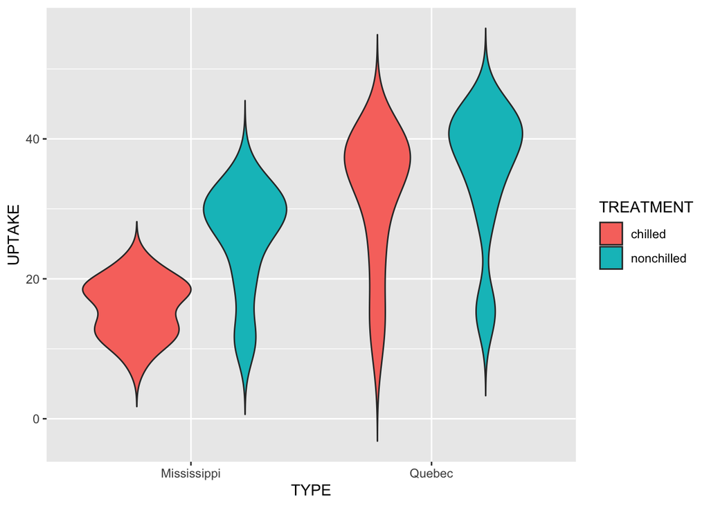

```r
plant_CO2 %>%
   select(TYPE, UPTAKE, TREATMENT) %>%
   ggplot(aes(x = TYPE,
              y = UPTAKE)) +
   geom_violin(aes(fill = TREATMENT), trim=F)
```

# Loading qPCR data from multiple files

- Download a set of qPCR experiments results [here as a zip archive](https://biostat2.uni.lu/practicals/data/pcr.zip) to the `data` sub-folder.
- Decompress the zip archive to the `data` sub-folder of your project.

You can run the following command in R to decompress the file:

```r
unzip(here::here("data", "pcr.zip"), exdir = "data/pcr")
```

This will create a sub-folder `data/pcr` and extract the files there.

These qPCR results were obtained from 2 different samples and were replicated 5 times each. They are stored in **10** different files. A filename looks like `mlc1_1.csv` where

- the first number is the **sample id**
- the second the **replicate id**.

#### Check that your file locations are correct

```r
dir(here::here("data", "pcr"), full.names = FALSE)
```

```
##  [1] "mlc1_1.csv" "mlc1_2.csv" "mlc1_3.csv" "mlc1_4.csv" "mlc1_5.csv"
##  [6] "mlc2_1.csv" "mlc2_2.csv" "mlc2_3.csv" "mlc2_4.csv" "mlc2_5.csv"
```

## Read in the qPCR results

The files exhibits a `csv` extension: you might think that the delimiter is a comma.

Let `vroom` doing the job for us.

##### Use `vroom` to import the file `mlc1_1.csv`

```r
vroom("data/pcr/mlc1_1.csv")
```

```
## Rows: 96
## Columns: 5
## chr [4]: well, gene, type, flag
## dbl [1]: Ct
##
## Pass a specification to the `col_types` argument to quiet this message
```

```
## # A tibble: 96 x 5
##    well  gene      Ct type  flag
##    <chr> <chr>  <dbl> <chr> <chr>
##  1 A1    gene1   33.6 data  OK
##  2 A2    gene2   22.4 data  OK
##  3 A3    gene3   31.8 data  OK
##  4 A4    gene4   30.2 data  OK
##  5 A5    gene5   33.1 data  OK
##  6 A6    gene6   33.8 data  OK
##  7 A7    gene7   31.0 data  OK
##  8 A8    gene8   16.3 data  OK
##  9 A9    gene9   32.6 data  OK
## 10 A10   gene10  30.1 data  OK
## # … with 86 more rows
```

The delimiter was a space (" ")

## Get a single tibble tidy out of all files

Instead of getting a list of multiple tibbles we can bind them altogether to create a single one.

`vroom` can actually achieve this if the input is a list of file paths, it merges them into **one** `tibble` **and** allows for keeping track of the **filename**.

An optional `id` option allows to save the `path` to keep track of the file of origin. Let’s name this `id` column `"file"` and save the resulting tibble of 96x10 rows as `pcr_data`

##### Use `dir()` to create a vector named `pcr_files` which contains the path to all 10 data files

You can get some help using `?dir` in particular to adjust the `full.names` argument to `TRUE`.

Then, we obtain the full path to each file, necessary to access the data.

```r
vroom(dir(path = "data/pcr", full.names = T), id = "file")
```

```
## Rows: 960
## Columns: 6
## chr [4]: well, gene, type, flag
## dbl [1]: Ct
##
## Pass a specification to the `col_types` argument to quiet this message
```

```
## # A tibble: 960 x 6
##    file                well  gene      Ct type  flag
##    <chr>               <chr> <chr>  <dbl> <chr> <chr>
##  1 data/pcr/mlc1_1.csv A1    gene1   33.6 data  OK
##  2 data/pcr/mlc1_1.csv A2    gene2   22.4 data  OK
##  3 data/pcr/mlc1_1.csv A3    gene3   31.8 data  OK
##  4 data/pcr/mlc1_1.csv A4    gene4   30.2 data  OK
##  5 data/pcr/mlc1_1.csv A5    gene5   33.1 data  OK
##  6 data/pcr/mlc1_1.csv A6    gene6   33.8 data  OK
##  7 data/pcr/mlc1_1.csv A7    gene7   31.0 data  OK
##  8 data/pcr/mlc1_1.csv A8    gene8   16.3 data  OK
##  9 data/pcr/mlc1_1.csv A9    gene9   32.6 data  OK
## 10 data/pcr/mlc1_1.csv A10   gene10  30.1 data  OK
## # … with 950 more rows
```

```r
#vroom(fs::dir_ls("data/pcr/", full.names = T), id = "file") also worked
```

##### Read all 10 files at once with `vroom`, using `id = "file"` to add filenames as an extra column. Assign the name `pcr_data`

```r
pcr_data <- vroom(dir(path = "data/pcr", full.names = T), id = "file")
```

```
## Rows: 960
## Columns: 6
## chr [4]: well, gene, type, flag
## dbl [1]: Ct
##
## Pass a specification to the `col_types` argument to quiet this message
```

##### Is this dataset tidy?

No, samples and replicates should have their own column

##### Extract the sample (`mlc1` or `mlc2`) and replicate number (1 to 5) into dedicated columns, assign the name `pcr_data_tidy`

Several options to achieve this are available. The most elegant is `str_extract()` with appropriate regular expressions. You can also get rid of the `file` column afterwards.

But extracting the filenames without extension and use `separate()` is also an alternative.

For the regular expression, if you want to extract the digit **after** the `_` you can use the positive look-behind assertion: `"(?<=_)\\d"`

```r
pcr_data_tidy <- pcr_data %>%
   mutate(sample = str_extract(file, ".{3}[0-9]{1}"),
          replicate = str_extract(file, "(?<=_)\\d+")) %>%
   select(-file)
```

Of note, the resulting **tidy** `tibble` should be:

```
# A tibble: 960 x 7
   well  gene      Ct type  flag  sample replicate
   <chr> <chr>  <dbl> <chr> <chr> <chr>  <chr>
 1 A1    gene1   33.6 data  OK    mlc1   1
 2 A2    gene2   22.4 data  OK    mlc1   1
 3 A3    gene3   31.8 data  OK    mlc1   1
 4 A4    gene4   30.2 data  OK    mlc1   1
 5 A5    gene5   33.1 data  OK    mlc1   1
 6 A6    gene6   33.8 data  OK    mlc1   1
 7 A7    gene7   31.0 data  OK    mlc1   1
 8 A8    gene8   16.3 data  OK    mlc1   1
 9 A9    gene9   32.6 data  OK    mlc1   1
10 A10   gene10  30.1 data  OK    mlc1   1
# … with 950 more rows
```

##### Check that for both samples, all `flag` are **OK** by counting them

```r
pcr_data_tidy %>%
   group_by(sample) %>%
   count(flag)
```

```
## # A tibble: 2 x 3
## # Groups:   sample [2]
##   sample flag      n
##   <chr>  <chr> <int>
## 1 mlc1   OK      480
## 2 mlc2   OK      480
```

##### Now that the data is tidy, plot the distribution of Ct values

- `replicate` on the x-axis
- `sample` as facet (2 columns)
- geometries, you can combine both a violin plot and the `ggbeeswarm::geom_quasirandom`

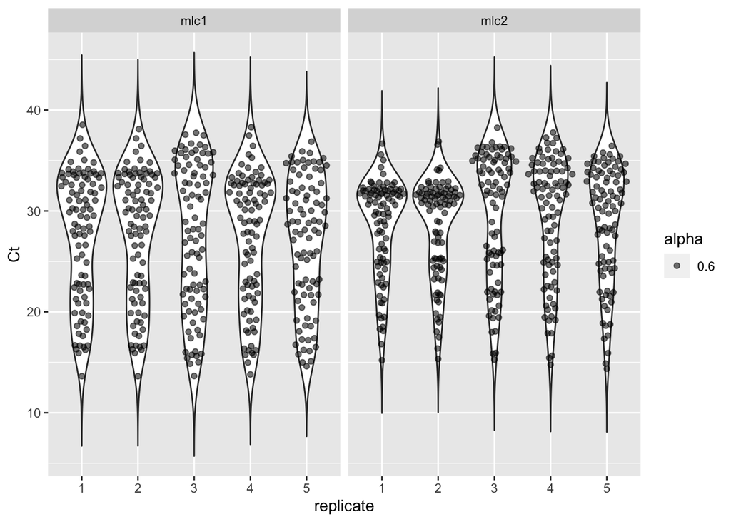

```r
pcr_data_tidy %>%
   ggplot(aes(x = replicate,
              y = Ct)) +
   geom_violin(trim = F) +
   facet_wrap(~ sample) +
   ggbeeswarm::geom_quasirandom(aes(alpha = 0.6))
```